# Summative Assessment 1

## Boxplot of Purchase Amount

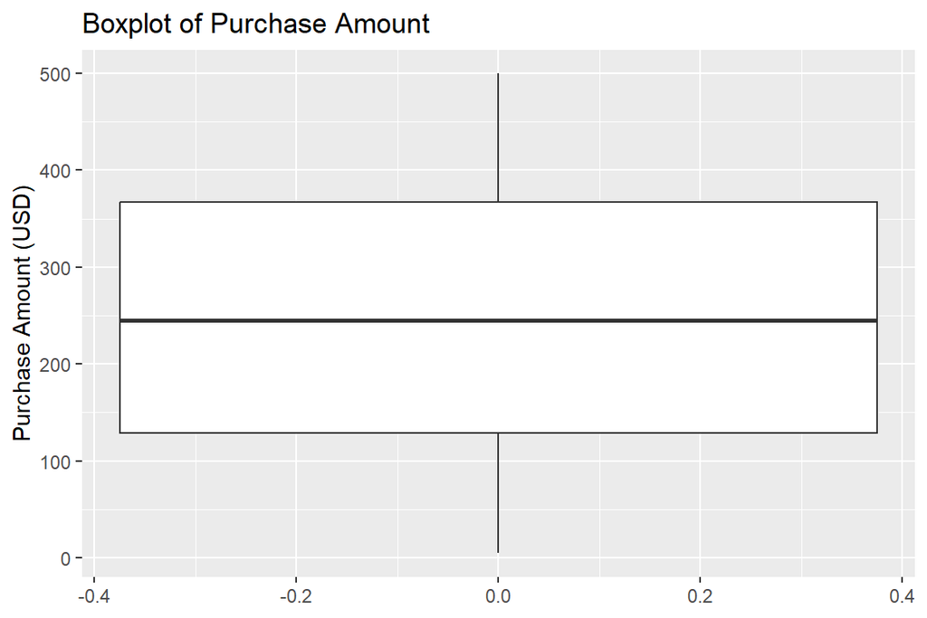

```r
ggplot(ecommerce, aes(y = Purchase_Amount)) +
geom_boxplot() +
labs(
title = "Boxplot of Purchase Amount",
y = "Purchase Amount (USD)"
)
```

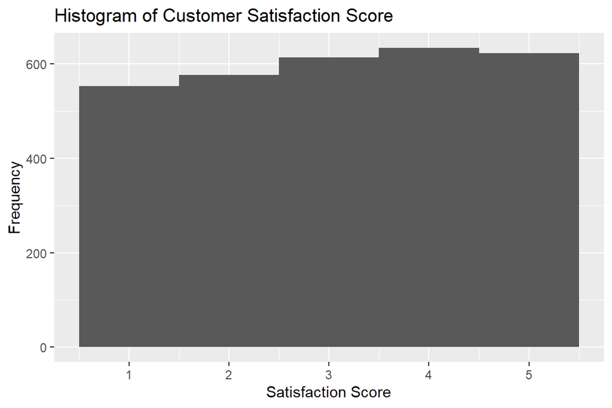

```r
ggplot(ecommerce, aes(x = Satisfaction_Score)) +
geom_histogram(bins = 5) +
labs(
title = "Histogram of Customer Satisfaction Score",
x = "Satisfaction Score",
y = "Frequency"
)
```

# Measures of Central Tendency and Spread

```r
mean(ecommerce$Purchase_Amount)
```

```
## [1] 247.9625
```

```r
median(ecommerce$Purchase_Amount)
```

```
## [1] 245.09
```

```r
mode_value <- names(sort(table(ecommerce$Purchase_Amount), decreasing = TRUE))[1]
mode_value
```

```
## [1] "29.33"
```

```r
var(ecommerce$Purchase_Amount)
```

```
## [1] 19845.99
```

```r
sd(ecommerce$Purchase_Amount)
```

```
## [1] 140.8758
```

```r
IQR(ecommerce$Purchase_Amount)
```

```
## [1] 238.505
```

# Density Comparison by Gender

## Browsing Time by Gender

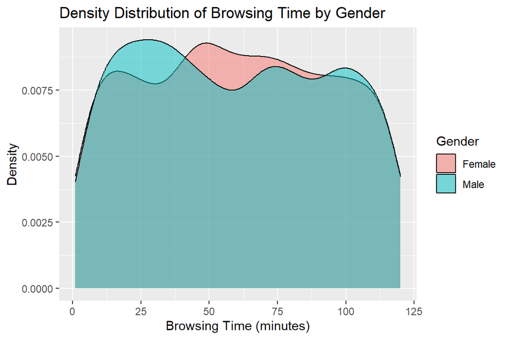

```r
ggplot(ecommerce, aes(x = Browsing_Time, fill = Gender)) +
geom_density(alpha = 0.5) +
labs(
title = "Density Distribution of Browsing Time by Gender",
x = "Browsing Time (minutes)", y = "Density"
)
```

## Purchase Amount by Gender

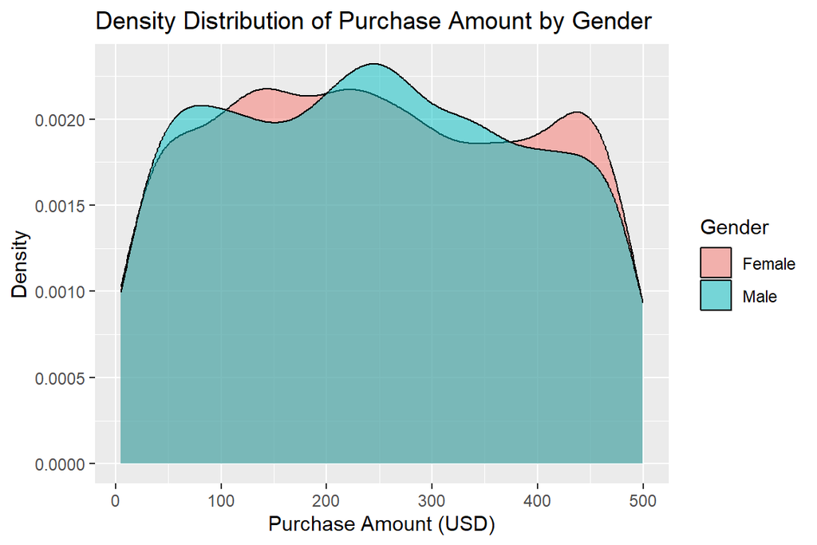

```r
ggplot(ecommerce, aes(x = Purchase_Amount, fill = Gender)) +
geom_density(alpha = 0.5) +
labs(
title = "Density Distribution of Purchase Amount by Gender",
x = "Purchase Amount (USD)",
y = "Density"
)
```

# Transformation of Browsing Time

## Original Distribution

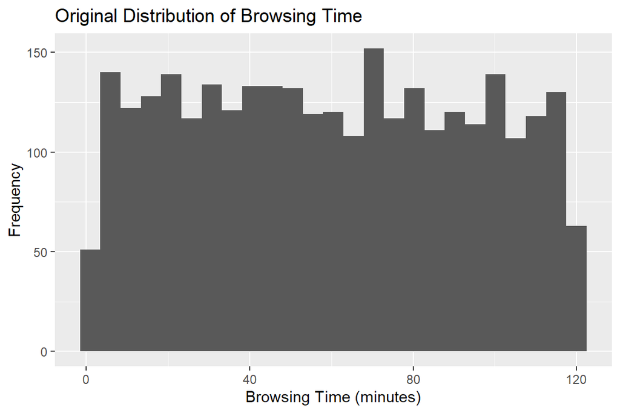

```r
ggplot(ecommerce, aes(x = Browsing_Time)) +
geom_histogram(bins = 25) +
labs(
title = "Original Distribution of Browsing Time",
x = "Browsing Time (minutes)",
y = "Frequency"
)
```

## Log Transformation of Browsing Time

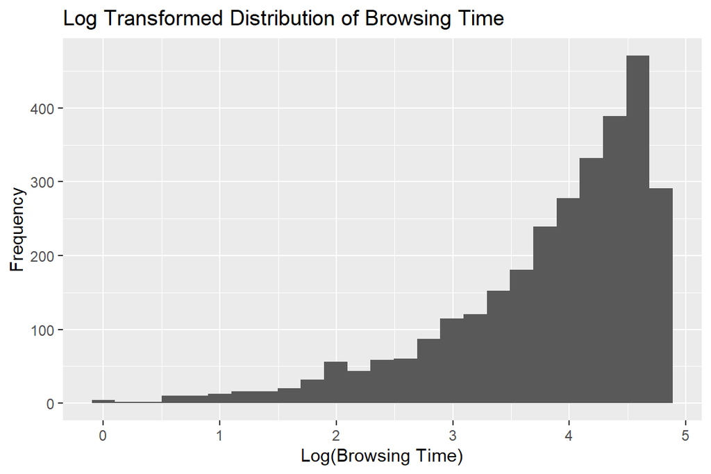

```r
ecommerce$log_browsing <- log(ecommerce$Browsing_Time)

ggplot(ecommerce, aes(x = log_browsing)) +
  geom_histogram(bins = 25) +
  labs(
    title = "Log Transformed Distribution of Browsing Time",
    x = "Log(Browsing Time)",
    y = "Frequency"
  )
```

# Simple Linear Regression Model

## Model Fitting

```r
purchase_lm <- lm(Purchase_Amount ~ Browsing_Time, data = ecommerce)
summary(purchase_lm)
```

```
##
## Call:
## lm(formula = Purchase_Amount ~ Browsing_Time, data = ecommerce)
##
## Residuals:
##      Min       1Q   Median       3Q      Max
## -244.867 -120.473   -2.946  118.246  254.069
##
## Coefficients:
##                Estimate Std. Error t value Pr(>|t|)
## (Intercept)   252.65596    5.17524  48.820   <2e-16 ***
## Browsing_Time  -0.07839    0.07501  -1.045    0.296
## ---
## Signif. codes:  0 '***' 0.001 '**' 0.01 '*' 0.05 '.' 0.1 ' ' 1
##
## Residual standard error: 140.9 on 2998 degrees of freedom
## Multiple R-squared:  0.0003642,  Adjusted R-squared:  3.075e-05
## F-statistic: 1.092 on 1 and 2998 DF,  p-value: 0.2961
```

## Model Interpretation

The fitted linear regression model is expressed as

$$Purchase\_Amount = \beta_0 + \beta_1(Browsing\_Time)$$

Slope: The estimated output for the slope shows the predicted change in purchase amount for every additional minute spent browsing the website before making a transaction.

Intercept: The intercept represents the predicted purchase amount when browsing time is set to zero minutes.

## Scatter Plot of Purchase Amount vs Browsing Time

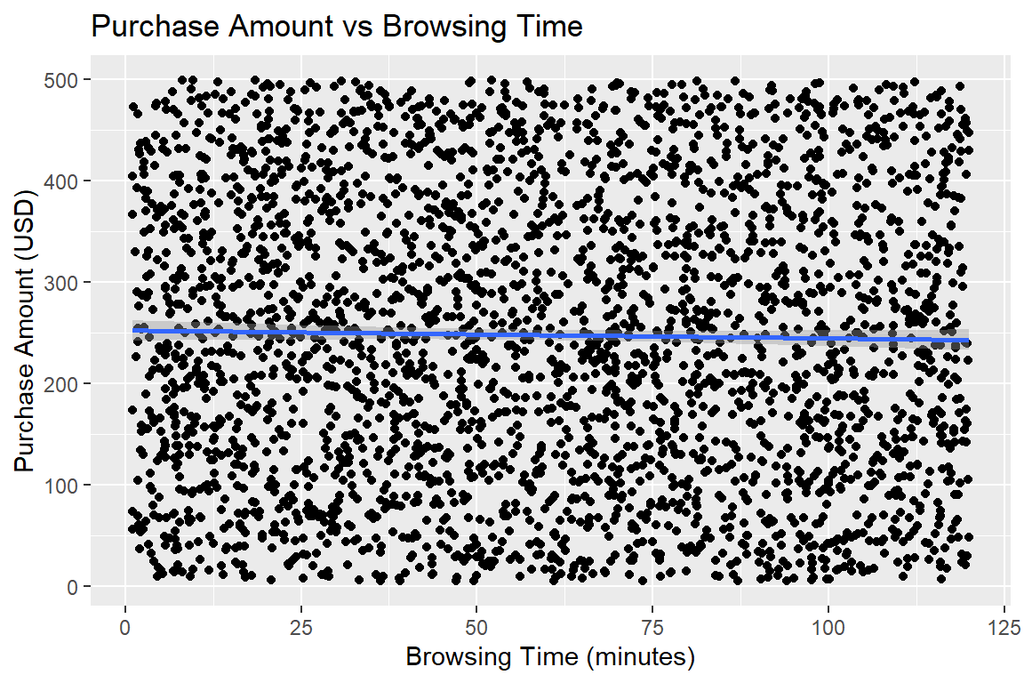

```r
ggplot(ecommerce, aes(x = Browsing_Time, y = Purchase_Amount)) +
  geom_point() +
  geom_smooth(method = "lm") +
  labs(
    title = "Purchase Amount vs Browsing Time",
    x = "Browsing Time (minutes)",
    y = "Purchase Amount (USD)"
  )
```

# Bivariate Analysis

## Purchase Amount vs Number of Items

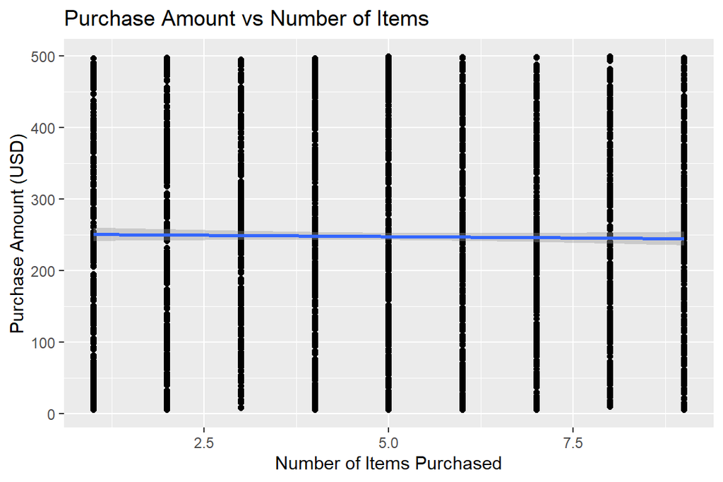

```r
ggplot(ecommerce, aes(x = Number_of_Items, y = Purchase_Amount)) +
  geom_point() +
  geom_smooth(method = "lm") +
  labs(
    title = "Purchase Amount vs Number of Items",
    x = "Number of Items Purchased",
    y = "Purchase Amount (USD)"
  )
```

## Polynomial Regression Model

```r
poly_model <- lm(Purchase_Amount ~ poly(Browsing_Time, 2), data = ecommerce)
summary(poly_model)
```

```
##
## Call:
## lm(formula = Purchase_Amount ~ poly(Browsing_Time, 2), data = ecommerce)
##
## Residuals:
##     Min      1Q  Median      3Q     Max
## -245.47 -120.41   -3.49  118.25  255.85
##
## Coefficients:
##                         Estimate Std. Error t value Pr(>|t|)
## (Intercept)              247.963      2.572  96.397   <2e-16 ***
## poly(Browsing_Time, 2)1 -147.227    140.892  -1.045    0.296
## poly(Browsing_Time, 2)2  -68.129    140.892  -0.484    0.629
## ---
## Signif. codes:  0 '***' 0.001 '**' 0.01 '*' 0.05 '.' 0.1 ' ' 1
##
## Residual standard error: 140.9 on 2997 degrees of freedom
## Multiple R-squared:  0.0004422,  Adjusted R-squared:  -0.0002249
## F-statistic: 0.6629 on 2 and 2997 DF,  p-value: 0.5154
```

## LOESS Smoothing

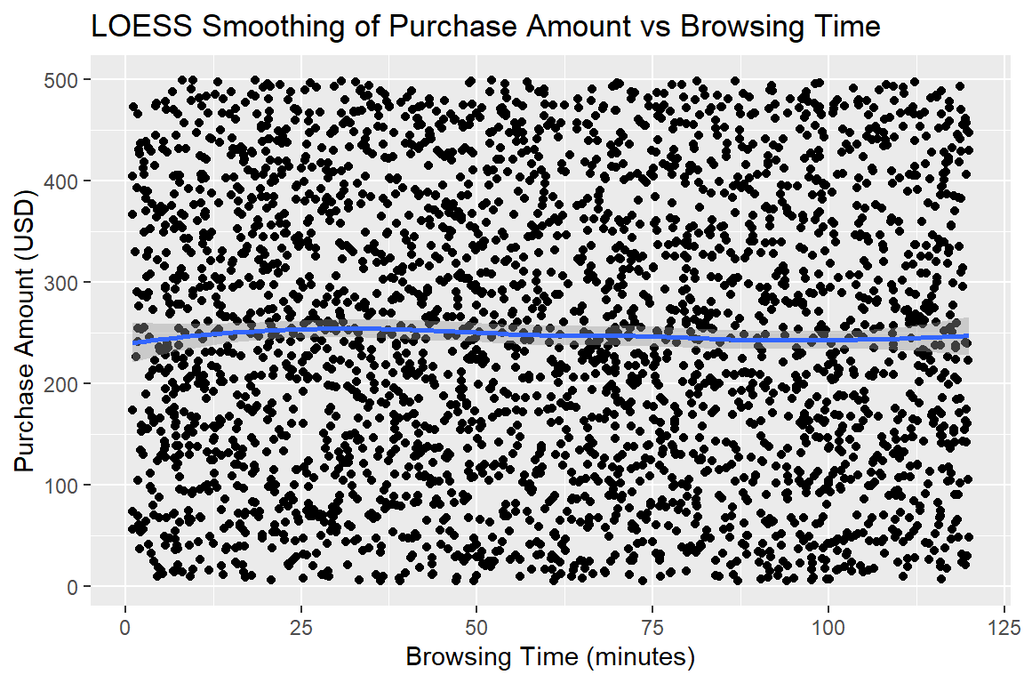

```r
ggplot(ecommerce, aes(x = Browsing_Time, y = Purchase_Amount)) +
  geom_point() +
  geom_smooth(method = "loess") +
  labs(
    title = "LOESS Smoothing of Purchase Amount vs Browsing Time",
    x = "Browsing Time (minutes)",
    y = "Purchase Amount (USD)"
  )
```

## Robust Regression

```r
robust_model <- rlm(Purchase_Amount ~ Browsing_Time, data = ecommerce)
summary(robust_model)
```

```
##
## Call: rlm(formula = Purchase_Amount ~ Browsing_Time, data = ecommerce)
## Residuals:
##      Min       1Q   Median       3Q      Max
## -244.818 -120.331   -2.848  118.291  254.289
##
## Coefficients:
##               Value    Std. Error t value
## (Intercept)   252.6462   5.3363    47.3448
## Browsing_Time  -0.0803   0.0773    -1.0378
##
## Residual standard error: 176.9 on 2998 degrees of freedom
```

# Trivariate / Hypervariate Analysis

## Interaction Plot

[figure not shown]

```r
interaction.plot(
  ecommerce$Category,
  ecommerce$Browsing_Time,
  ecommerce$Purchase_Amount,
  col = 1:5,
  lwd = 2
)
```

## Coplots

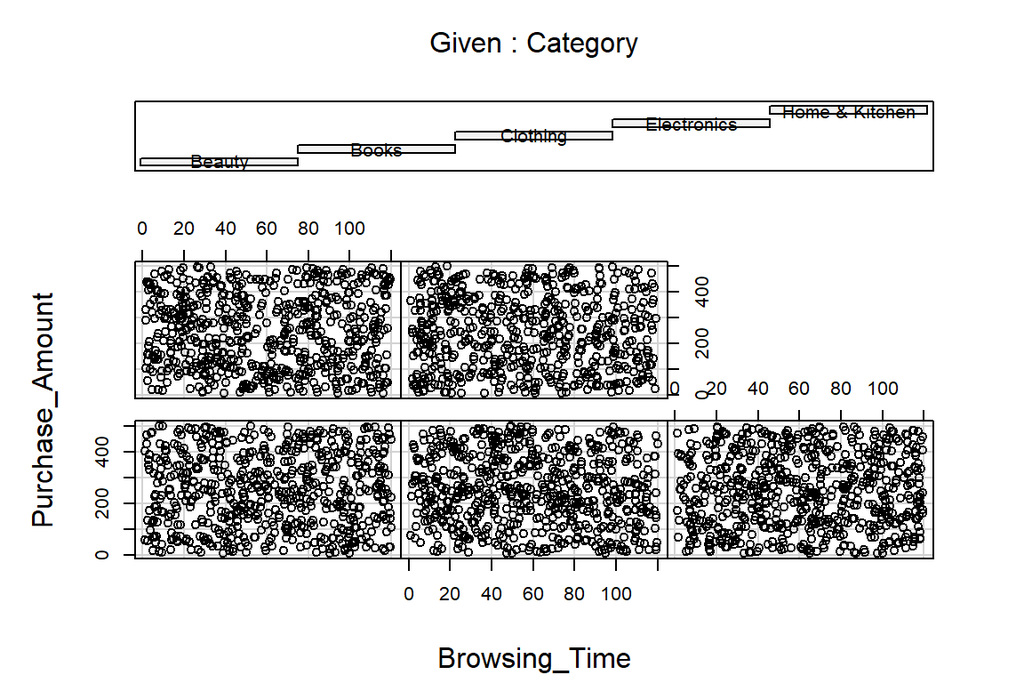

```r
coplot(Purchase_Amount ~ Browsing_Time | Category, data = ecommerce)
```

## Level Plot

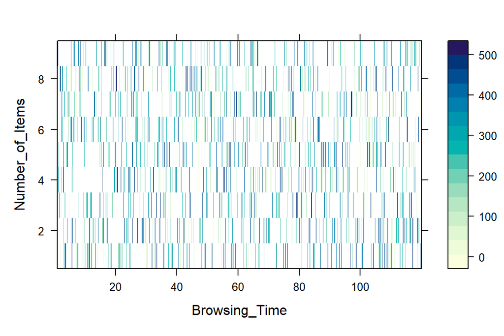

```r
levelplot(Purchase_Amount ~ Browsing_Time * Number_of_Items, data = ecommerce)
```

# Multiple Regression Model

## Model Fitting

```r
multi_model <- lm(
  Purchase_Amount ~ Browsing_Time + Number_of_Items + Satisfaction_Score,
  data = ecommerce
)

summary(multi_model)
```

```
##
## Call:
## lm(formula = Purchase_Amount ~ Browsing_Time + Number_of_Items +
##     Satisfaction_Score, data = ecommerce)
##
## Residuals:
##      Min       1Q   Median       3Q      Max
## -250.668 -120.856   -2.846  118.899  255.664
##
## Coefficients:
##                     Estimate Std. Error t value Pr(>|t|)
## (Intercept)        261.34993    9.24929  28.256   <2e-16 ***
## Browsing_Time       -0.07954    0.07504  -1.060    0.289
## Number_of_Items     -0.78321    1.00497  -0.779    0.436
## Satisfaction_Score  -1.53871    1.83444  -0.839    0.402
## ---
## Signif. codes:  0 '***' 0.001 '**' 0.01 '*' 0.05 '.' 0.1 ' ' 1
##
## Residual standard error: 140.9 on 2996 degrees of freedom
## Multiple R-squared:  0.0007932,  Adjusted R-squared:  -0.0002073
## F-statistic: 0.7928 on 3 and 2996 DF,  p-value: 0.4978
```

## Model Interpretation

In this multiple regression model variables such as browsing time, number of items purchased, and customer satisfaction are examined to make an accurate assumption in what factors influence purchase amounts.

# Reflection

Concluding this, this activity reinforced the importance of interpretation in complex and multifaceted data. This shows how exploratory data analysis is a crucial first step in analyzing different datasets.